# CUNY DATA 607 - Project 3

# Project Overview

## Team Members

- Donald Butler
- Nick Oliver
- Jeffrey Parks
- Mark Schamfield

## GitHub

https://github.com/nolivercuny/data607-team-6-project-3

## Project Objective

Use data to answer the question, “Which are the most valued data science skills?”

- Identify viable data sources.
- Load data into a relational database with normalized tables.
- Perform tidying, transformaiton and exploratory data analytis in R.
- Analyze data and show findings.

## Project Approach

We considered several potential data sources for this project, including:

- Scraping “Data Scientist” job postings from websites like Indeed and LinkedIn.
- Examining Reddit data science-related subreddits for questions related to “skills” or “careers”
- Looking at Python, NPM or R packages that mention specific skills
- Reviewing Youtube videos that mention learning some data science skill
- Scanning question/interview study guides that are targeted at data scientists
- Finding LinkedIn public profiles of employed data scientists and what skills they list
- Analyzing StackOverflow data science-related pages

After initial discussion, we decided to attempt the first option, scraping ‘Data Scientist’ job listings.

Our initial idea was to leverage an API endpoint from one of the popular services, such as Indeed.com. However, we found that while Indeed does produce an API, it restricts access to verified Publishers of job postings. In the interests of time, and since we had some team members with experience in web scraping, we pulled job listings directly from the from LinkedIn website using a popular browser automation tool, **Selenium** in Python.

Once we had the data in hand, we identified a multi-step approach to analysis:

- Use a text mining package such **tidytext** to tokenize keywords in the job descriptions
- Manually scan the tokenized keywords for terms describing discrete job skills, and filter out non-skill-related terms.
- Built a relational database with individual tables for Job Listings, Companies and Skills
- Query the database to analyze the counts, frequency and trends.

# Data Acquisition

Our dataset was based on a search on LinkedIn.com for job listings matching the term “Data Scientist” in the New York, NY Metropolitan region on the evening of October 12, 2021:

https://www.linkedin.com/jobs/search/?geoId=90000070&keywords=data%20scientist&location=New%20York%20City%20Metropolitan%20Area

Results were scraped from an automated browser session managed by the **Selenium** library using **Chromedriver**. The Selenium API received instructions from a Python Jupyter Notebook, and was executed in two sessions.

Results were saved as **job_listings_final.csv**.

The Jupyter Notebook, Selenium API script and supporting data can be found in: https://github.com/nolivercuny/data607-team-6-project-3/tree/master/data/jobs-scraper

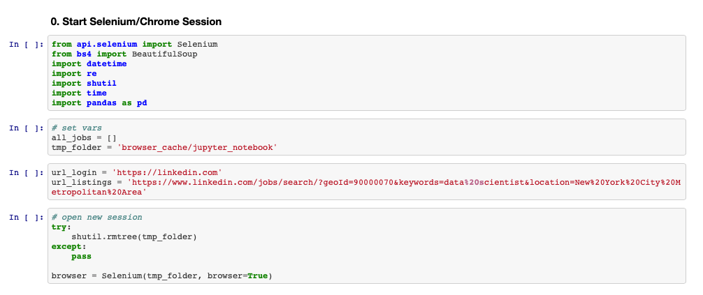

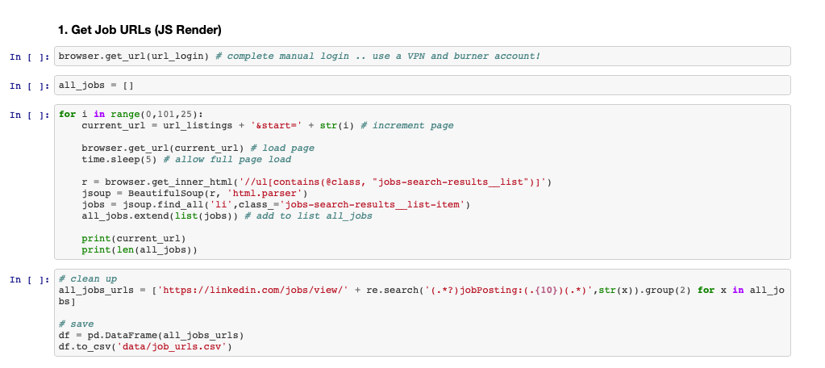

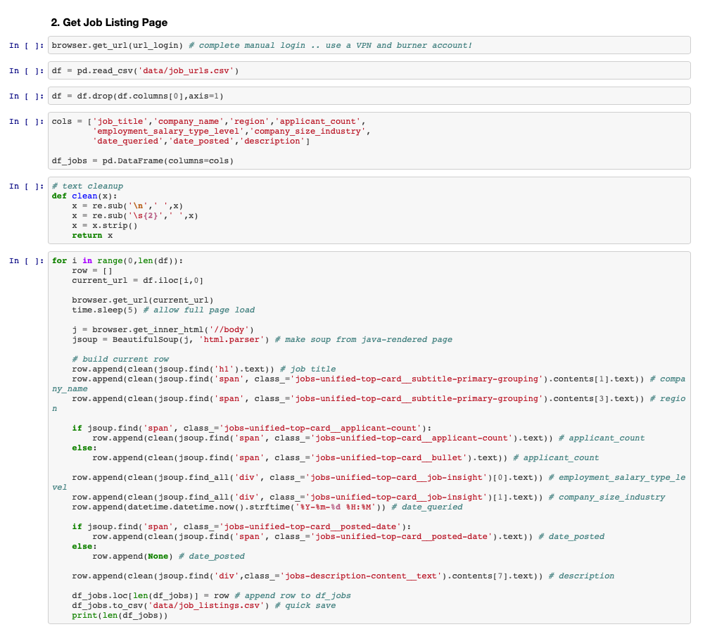

# Data Transformation

Our first step was to transform the raw job descriptions into tokenized fields for analysis. We decided to create one table with all words (except for “stop words”) to analyze overall frequency at a high level, and a second table that would identify common multi-word combinations called “ngrams.”

This second approach would correctly return the frequency of phrases such as “Machine Learning”, instead of separate results for “Machine” and “Learning”. We further filtered this second table manually to identify actual job skills, and not extraneous information (such as company names and other filler text.)

**Load the job descriptions dataset**

```r
urlfile<-"https://raw.githubusercontent.com/nolivercuny/data607-team-6-project-3/master/data/job_listings_final.csv"
jobdat <- read_csv(url(urlfile))
jobdat<-data_frame(jobdat)
```

**Create jobdata_words.csv**

We created this table to analyze overall term frequency, using **tidytext** to un-nest the job descriptions into indivdual words, and removing “stop words” (the, of, to, etc)

```r
jobdat_word<- unnest_tokens(
  jobdat,
  word,
  description,
  token= "words",
  format=c("text"),
  to_lower=TRUE,
  drop=TRUE,
  collapse=NULL,
)

jobdat_word <-jobdat_word %>%
  anti_join(stop_words)

write_csv(jobdat_word,'data/jobdata_words.csv')
```

**Create jobdat_ngrams.csv**

We created this file to analyze terms and phrases that meet criteria for “hard skills.” Using **tidytext**, created ngrams of 1, 2, and 3 words, filtered out the common stop_words, and then did a count and filtered the rows that occurred at least 10 times within the raw dataset. The resulting 6015 rows were exported to a .csv file used to manually determine which terms described actual job skills and which did not.

```r
jobdat_1gram <- jobdat %>%
  unnest_tokens(ngram,description,token='ngrams',n=1,format='text',
                drop=TRUE,to_lower=TRUE) %>%
  filter(!ngram %in% stop_words$word) %>%
  count(ngram,sort = TRUE) %>%
  filter(n >= 10)

jobdat_2gram <- jobdat %>%
  unnest_tokens(ngram,description,token='ngrams',n=2,format='text',
                drop=TRUE,to_lower=TRUE) %>%
  separate(ngram,c('word1','word2'),sep = " ") %>%
  filter(!word1 %in% stop_words$word) %>%
  filter(!word2 %in% stop_words$word) %>%
  unite(ngram, c('word1','word2'), sep = " ") %>%
  count(ngram,sort = TRUE) %>%
  filter(n >= 10)

jobdat_3gram <- jobdat %>%
  unnest_tokens(ngram,description,token='ngrams',n=3,format='text',
                drop=TRUE,to_lower=TRUE) %>%
  separate(ngram,c('word1','word2','word3'),sep = " ") %>%
  filter(!word1 %in% stop_words$word) %>%
  filter(!word2 %in% stop_words$word) %>%
  filter(!word3 %in% stop_words$word) %>%
  unite(ngram, c('word1','word2','word3'), sep = " ") %>%
  count(ngram,sort = TRUE) %>%
  filter(n >= 10)

jobdat_ngrams <- jobdat_1gram %>%
  rbind(jobdat_2gram) %>%
  rbind(jobdat_3gram) %>%
  arrange(desc(n))

jobdat_ngrams %>%
  write.table(file = './jobdat_ngrams.csv',quote = FALSE,
              sep = '\t', row.names = FALSE)
```

# Database Operations

To support the data analysis, we transformed the raw dataset into a relational database using **Sqlite**, a file-based format that is both fast and portable, so that all team members could access the database without having to manage any kind of server.

## Create Database and Tables

```r
# For testing - use in-memory DB
con <- dbConnect(RSQLite::SQLite(), dbname = ":memory:")

# Uncomment to manipulate real DB
#con <- dbConnect(RSQLite::SQLite(), dbname = "project3_job_skills.db")
```

```r
baseUrl <- "https://raw.githubusercontent.com/nolivercuny/data607-team-6-project-3/master/sql/"
tables <- c("company", "job_listing", "job_listing_skill","job_listing_word")
for (table in tables) {
  fileUrl <- paste(baseUrl, table,".sql",sep = "")
  createTableStatement <- getURL(fileUrl)
  print(paste("Creating ", table, " table"))
  dbSendQuery(con, createTableStatement)
}
```

**Load Data From CSV**

```r
urlfile<-"https://raw.githubusercontent.com/nolivercuny/data607-team-6-project-3/master/data/job_listings_final.csv"
jobdat <- read_csv(url(urlfile))
```

**Populate company table**

Unique row per company (420)

```r
companiesDf <- jobdat %>%
  select(company_name, company_size, industry) %>%
  distinct()

companiesDf$company_name <- companiesDf$company_name %>% replace_na("unknown")
dbWriteTable(con,"company",companiesDf, append=TRUE)
```

| `column_name` | `data_type` | `attrs` |
| --- | --- | --- |
| `id` | `int` | `pk` |
| `company_name` | `int` | `not null` |
| `company_size` | `int` | `null` |
| `industry` | `int` | `null` |

**Populate job_listing table**

Unique row per job listing (849)

```r
# Remove columns that are in the company table
jobListingDf <- jobdat %>% select(-c("company_size", "industry"))

# Fix the one company name that is NA
jobListingDf$company_name <- jobListingDf$company_name %>% replace_na("unknown")

# Read companies to get company ID for joining
companiesWithId <- dbReadTable(con,"company")

# Join job listing with company to populate id, then drop company-specific cols
# rename id column to company id
joined <- left_join(jobListingDf, companiesWithId, by="company_name") %>%
  select(-c("company_size", "industry","company_name")) %>%
  rename(company_id = id)

#write dataframe to job_listing table
dbWriteTable(con, "job_listing", joined, append=TRUE)
```

| `column_name` | `data_type` | `attrs` |
| --- | --- | --- |
| `id` | `int` | `pk` |
| `search_rank` | `int` | `not null` |
| `job_title` | `text` | `not null` |
| `region` | `text` | `not null` |
| `applicant_count` | `int` | `null` |
| `salary` | `text` | `null` |
| `employment_type` | `text` | `not null` |
| `career_level` | `text` | `null` |
| `description` | `text` | `null` |
| `date_queried` | `text` | `null` |
| `date_posted` | `text` |  |
| `company_id` | `int` | `fk` |

**Populate job_listing_word table**

Unique row per word (18,000)

```r
wordsDataUrl <- "https://raw.githubusercontent.com/nolivercuny/data607-team-6-project-3/master/data/jobdata_words.csv"
wordsJobListingData <- read_csv(url(wordsDataUrl))
wordsJobListingData<-data_frame(wordsJobListingData)

wordsDf <- wordsJobListingData %>% select(search_rank, word)
jobListingWithId <- dbReadTable(con,"job_listing")
joinedWords<-left_join(wordsDf, jobListingWithId, by="search_rank") %>%
  select(id, word) %>%
  rename(job_listing_id = id, skill = word)
dbWriteTable(con,"job_listing_word", joinedWords, append=TRUE)
```

| `column_name` | `data_type` | `attrs` |
| --- | --- | --- |
| `id` | `int` | `pk` |
| `skill` | `text` | `not null` |

**Populate job_listing_skill table**

Unique row per tokenized skill (53).

We loop though the list of skills and use regex to determine if the skill is listed within the description text. A new attribute is created in the jobs data frame that indicates if the skill is required.

```r
skillsDataUrl <- "https://raw.githubusercontent.com/nolivercuny/data607-team-6-project-3/master/JobSkills.csv"
skillsData <- read_csv(url(skillsDataUrl))
skillsDf <-data_frame(skillsData)

jobListingWithId <- dbReadTable(con,"job_listing")
skillsTableDf <- data.frame(job_listing_id=integer(), skill=character())
for (i in 1:nrow(jobListingWithId)) {
  listing <- jobListingWithId[i,]
  for (j in 1:nrow(skillsDf)) {
    skill <- skillsDf[j,]
    detected <- str_detect(listing$description,
                           regex(paste('[^A-Z0-9]',skill,'[^A-Z0-9]',sep = ''),
                                 ignore_case = TRUE))
    if(detected==TRUE){
      skillsTableDf <- skillsTableDf %>%
        add_row(job_listing_id = listing$id, skill = skill$JobSkill)
    }
  }
}

dbWriteTable(con,"job_listing_skill", skillsTableDf, append=TRUE)
dbDisconnect(con)
```

| `column_name` | `data_type` | `attrs` |
| --- | --- | --- |
| `id` | `int` | `pk` |
| `job_listing_id` | `int` | `fk` |
| `skill` | `text` | `not null` |

# Exploratory Data Analysis

### Load from Database

```r
# replace with relative or remote path to db
dbLocation <-"/Users/jeff/Development/data607-team-6-project-3/data/project3_job_skills.db"
con <- dbConnect(RSQLite::SQLite(), dbname = dbLocation)

# get tables
tables <- dbListTables(con)
company_df <- dbReadTable(con, 'company')
listing_df <- dbReadTable(con, 'job_listing')
skills_df <- dbReadTable(con, 'job_listing_skill')
words_df <- dbReadTable(con, 'job_listing_word')

# construct fact tables
job_listings <- listing_df %>%
  inner_join(company_df, by = c('company_id' = 'id'))

job_listings_skills <- job_listings %>%
  inner_join(skills_df, by = c('id' = 'job_listing_id'))
```

## Frequency - All Terms

For our initial EDA, we wanted to look at the raw frequency of terms among all 849 job listings, and identify some of the most commonly-used words.

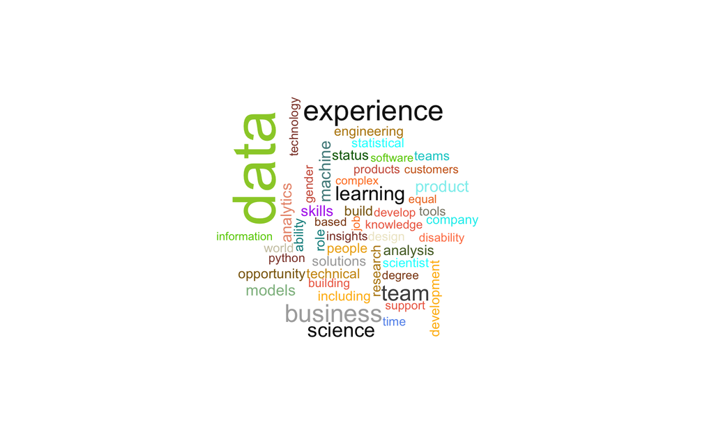

```r
words_df %>%
  count(skill) %>%
  with(wordcloud(skill,n,scale=c(4,0.5),max.words=50,
                 random.color = FALSE,rot.per=0.25,colors = colours()))
```

## Skills

### Soft Skills

The previous wordcloud effectively highlights both technical and “soft skill” terms with high frequencies. If we apply a manual filter for some of the common “soft skills” in our dataset, we get a clearer picture of what employers are looking for in this category from Data Scientists:

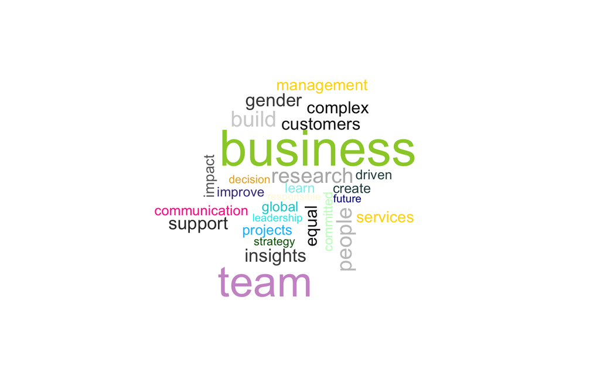

```r
soft_skills<-c("business","team","build","people","research","insights","gender","support","communication","equal","customers","complex","management","services","impact","projects","global","create","learn","strategy","driven","improve","committed","future","decision","leadership","responsible")

words_df %>%
  filter(skill %in% soft_skills) %>%
  count(skill) %>%
  with(wordcloud(skill,n,scale=c(4,0.5),max.words=50,
                 random.color = FALSE,rot.per=0.25,colors = colours()))
```

### Hard Skills

#### Technical Skills for Data Scientist or Data Analyst in New York, NY

Looking strictly at “hard skills” frequency, our analysis suggests that candidates should be “tri-lingual” in Python, R and SQL as foundational skills.

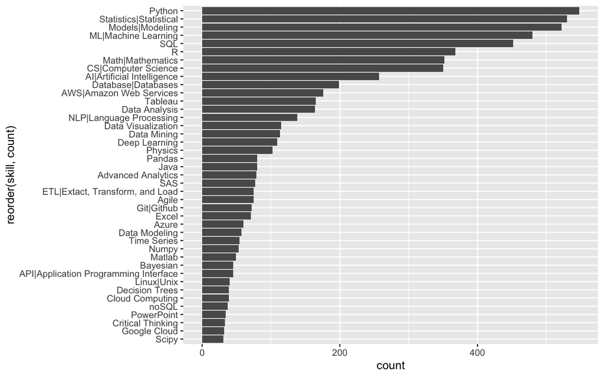

```r
job_listings_skills %>%
  filter(grepl('data scientist|data analyst',job_title,ignore.case = TRUE)) %>%
  group_by(skill) %>%
  summarize(count = n()) %>%
  filter(count >= 30) %>%
  ggplot(aes(x = reorder(skill,count), y = count)) + geom_bar(stat = 'identity') + coord_flip()
```

## Companies

### Companies posting Data Science jobs in New York, NY

As expected, FAANG companies dominated the listings but there was also strong activity in the Finance, Media and Healthcare sectors.

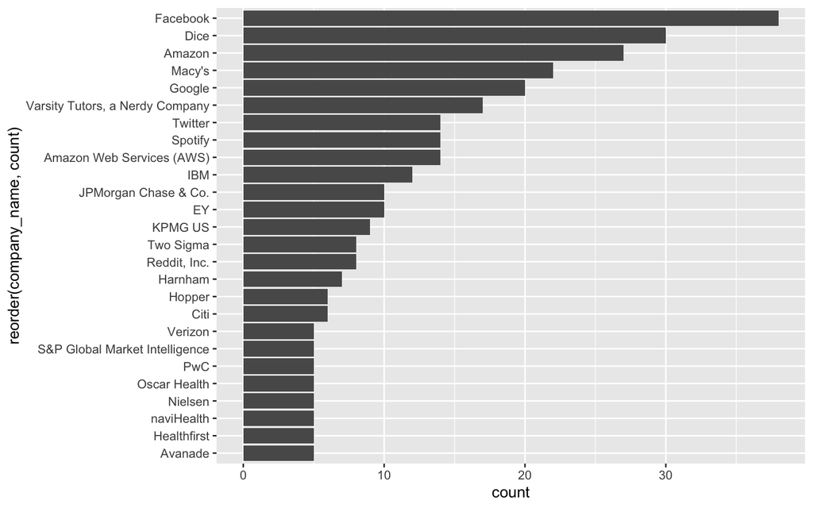

```r
job_listings %>%
  group_by(company_name) %>%
  summarize(count = n()) %>%
  filter(count >= 5) %>%
  ggplot(aes(x = reorder(company_name,count), y = count)) + geom_bar(stat = 'identity') + coord_flip()
```

### Companies requiring the most skills

Certain companies were very detailed in their postings, with high average frequency of technical skills outlined in their job descriptions.

```r
companySkillsCountDf <- dbGetQuery(con,
  "select c.company_name,
  count(jls.skill) as required_skills
  from job_listing jl
  join job_listing_skill jls on jl.id = jls.job_listing_id
  join company c on c.id = jl.company_id
  group by company_name
  order by required_skills desc;")

companyJobListingsCountDf <- dbGetQuery(con,
  "select c.company_name,
  count(jl.id) as number_job_listings
  from job_listing jl
  join company c on c.id = jl.company_id
  group by company_name
  order by number_job_listings desc;")

joinedDf <- left_join(companyJobListingsCountDf,
                      companySkillsCountDf,
                      by="company_name") %>%
  mutate(mean_skills_per_listing = round(required_skills / number_job_listings))

joinedDf %>%
  select(company_name, mean_skills_per_listing) %>%
  arrange(desc(mean_skills_per_listing)) %>%
  top_n(10, mean_skills_per_listing) %>%
  kable(format='simple')
```

| company_name | mean_skills_per_listing |
| --- | --- |
| Johnson & Johnson | 26 |
| Lexmark | 24 |
| Oracle | 21 |
| Disney Streaming | 21 |
| Nuveen, a TIAA company | 20 |
| Zebra Technologies | 19 |
| Sumitomo Mitsui Banking Corporation | 19 |
| Kubient | 19 |
| EVERSANA | 19 |
| Evolent Health | 18 |
| ViacomCBS | 18 |
| Venusgeo Solutions | 18 |
| The Mom Project | 18 |
| City Experiences | 18 |
| BMC Software | 18 |

# Conclusions

During our analysis, we also identified additional questions for further investigation, such as:

- How do Hard and Soft Skills vary by Industry and by Company?
- Are certain high-volume companies using basic job description templates? If so, what are the real differentiators from listing to listing?
- What specific mathematical and statistical skillsets are most desired/required?